# Likelihood & Maximum Likelihood

INFO 521 · Module 3 · Lecture A — From Loss to Likelihood

Greg Chism

College of Information Science · University of Arizona

August 2026

## Learning outcomes

By the end of Lecture A you should be able to:

1. **State the linear-Gaussian noise model** and read it generatively.
2. **Write the likelihood** $p(\mathbf{y}\mid\mathbf{X},\mathbf{w},\sigma^2)$ and the log-likelihood $\ell(\mathbf{w})$.
3. **Derive the MLE** — and show $\hat{\mathbf{w}}_{\text{MLE}}$ **is** the least-squares $\hat{\mathbf{w}}$ from Module 1.
4. **Estimate the noise** — $\hat{\sigma}^2$ — and explain why it is **biased**.

## Why squared error? (the debt from Module 1)

Module 1 *chose* the mean-squared-error loss

$$\mathcal{L}(\mathbf{w}) = \tfrac{1}{N}\,\lVert \mathbf{y} - \mathbf{X}\mathbf{w}\rVert_2^2$$

because it was smooth and penalized big misses. Reasonable — but a **choice**.

Today we *earn* it: squared error is what a **Gaussian noise model** implies. The accent hint on m1a’s loss slide was this lecture.

## The noise model

Assume each patient’s systolic BP is the linear signal **plus Gaussian noise**:

$$y_n = \mathbf{w}^{\!\top}\mathbf{x}_n + \varepsilon_n,
\qquad
\varepsilon_n \sim \mathcal{N}(0,\ \sigma^2)\ \ \text{independently.}$$

Equivalently, each observation is a **draw from a Gaussian centered on the line**:

$$p(y_n \mid \mathbf{x}_n, \mathbf{w}, \sigma^2)
= \mathcal{N}\!\left(y_n \,\middle|\, \mathbf{w}^{\!\top}\mathbf{x}_n,\ \sigma^2\right).$$

This is a **generative story**: fix $\mathbf{w}, \sigma^2$, and the model can *produce* datasets — the picture m3b’s repeated-datasets schematic draws.

## The Gaussian, in one slide

$$\mathcal{N}(y \mid \mu, \sigma^2)
= \frac{1}{\sqrt{2\pi\sigma^2}}
\exp\!\left(-\frac{(y-\mu)^2}{2\sigma^2}\right)$$

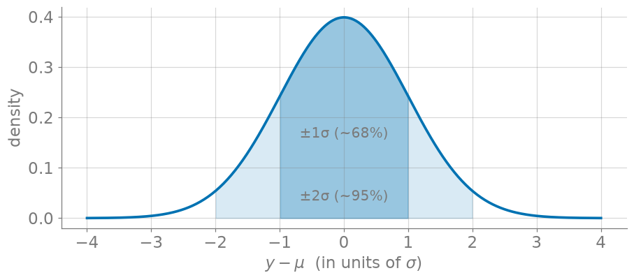

Figure 1: The Gaussian (illustrative): mean μ sets the center, σ sets the spread — ~68% within ±1σ, ~95% within ±2σ.

## The likelihood

The patients are independent, so the probability of the **whole dataset** is a product — read as a **function of the parameters** with the data fixed:

$$p(\mathbf{y}\mid\mathbf{X},\mathbf{w},\sigma^2)
= \prod_{n=1}^{N} \mathcal{N}\!\left(y_n \,\middle|\, \mathbf{w}^{\!\top}\mathbf{x}_n,\ \sigma^2\right)$$

- Data $(\mathbf{X}, \mathbf{y})$: **fixed** — it already happened.
- Parameters $(\mathbf{w}, \sigma^2)$: **free** — the knobs we turn.
- **The likelihood scores the knobs**: parameters under which the observed data are *more probable* score higher.

**Maximum likelihood**: pick the parameters that make the data you actually saw as probable as possible.

## The log-likelihood

Products of exponentials beg for a logarithm — we write the log-likelihood $\ell(\mathbf{w}) = \log p(\mathbf{y}\mid\mathbf{X},\mathbf{w},\sigma^2)$, reserving $\mathcal{L}$ for losses:

$$\ell(\mathbf{w}) = -\tfrac{N}{2}\log 2\pi \;-\; N\log\sigma
\;-\; \tfrac{1}{2\sigma^2}\sum_{n=1}^{N}\left(y_n - \mathbf{w}^{\!\top}\mathbf{x}_n\right)^2$$

Look at the $\mathbf{w}$-dependent part: it is **$-$(sum of squared errors), scaled**. Maximizing $\ell$ in $\mathbf{w}$ *is* minimizing squared error:

$$\arg\max_{\mathbf{w}} \ell(\mathbf{w})
\;=\;
\arg\min_{\mathbf{w}} \mathcal{L}(\mathbf{w}).$$

## The likelihood surface over NHANES

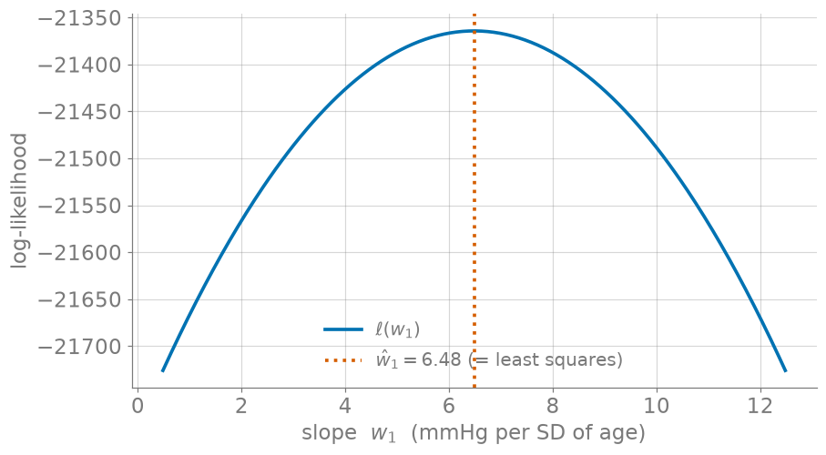

Figure 2: ℓ(w₁) for SBP on standardized age (intercept at ŵ₀): the peak IS the Module-1 least-squares slope.

## MLE for w: an old friend

Set the gradient of $\ell$ in $\mathbf{w}$ to zero:

$$\frac{\partial \ell}{\partial \mathbf{w}}
= \tfrac{1}{\sigma^2}\left(\mathbf{X}^{\!\top}\mathbf{y} - \mathbf{X}^{\!\top}\mathbf{X}\mathbf{w}\right)
= \mathbf{0}
\qquad\Longrightarrow\qquad
\boxed{\;\hat{\mathbf{w}}_{\text{MLE}} = \left(\mathbf{X}^{\!\top}\mathbf{X}\right)^{-1}\mathbf{X}^{\!\top}\mathbf{y}\;}$$

The **normal equations again** — $\sigma^2$ cancels entirely.

**Least squares = maximum likelihood under Gaussian noise.** Same $\hat{\mathbf{w}}$, better foundation: now it comes from a model, not a preference.

## Dividend 1: the noise gets estimated too

The loss treated the scatter around the line as a nuisance. The likelihood makes it a **parameter**. Setting $\partial\ell/\partial\sigma = 0$:

$$\hat{\sigma}^2
= \tfrac{1}{N}\sum_{n=1}^{N}\left(y_n - \hat{\mathbf{w}}^{\!\top}\mathbf{x}_n\right)^2
= \tfrac{1}{N}\left(\mathbf{y}^{\!\top}\mathbf{y} - \mathbf{y}^{\!\top}\mathbf{X}\hat{\mathbf{w}}\right)$$

— the **average squared residual** at the fitted line.

For SBP on standardized age: $\hat{\sigma} \approx 15.9$ mmHg — the model’s honest “give or take” for one patient.

## Model check: are the residuals Gaussian-ish?

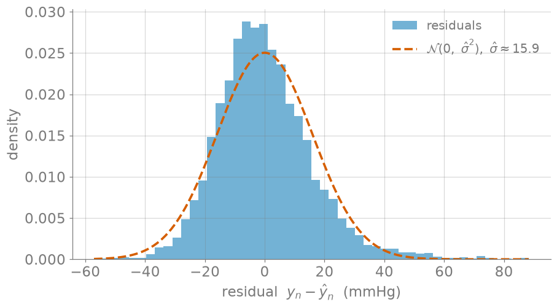

Figure 3: NHANES residuals vs. the fitted 𝒩(0, σ̂²): bell-ish, but right-skewed — models are assumptions, check them.

## Dividend 2 — with a catch: $\hat{\sigma}^2$ is biased

Averaging over repeated datasets from the generating process:

$$\mathbb{E}\!\left[\hat{\sigma}^2\right] = \frac{N - D}{N}\,\sigma^2 \;<\; \sigma^2
\qquad(D\ \text{fitted parameters})$$

- The fit **chases the sample**: residuals from $\hat{\mathbf{w}}$ are *systematically smaller* than the true errors from $\mathbf{w}$.
- Each fitted parameter eats one *degree of freedom* — hence the $N{-}D$.
- The classic repair divides by $N{-}D$ instead of $N$; at $N \approx 5{,}102$, $D = 2$, the difference is invisible — at $N = 10$ it is not.

## Seeing the bias

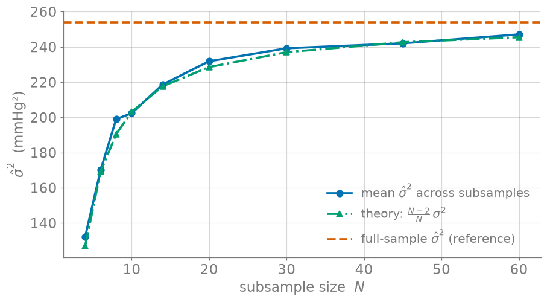

Figure 4: Mean σ̂² over 2,000 NHANES subsamples per size: small samples systematically UNDER-estimate the noise, tracking (N−2)/N · σ².

## What maximum likelihood buys

One framework, three purchases:

1. **A principled loss.** Squared error stops being a taste and becomes a *consequence* (of Gaussian noise). Different noise model ⇒ different loss.
2. **Noise as a first-class estimate.** $\hat{\sigma}^2$ quantifies patient-level scatter — the loss view had nowhere to put it.
3. **A road to uncertainty.** The *curvature* of $\ell$ at the peak says how sharply the data pin down $\hat{\mathbf{w}}$ — that is **Lecture B**.

And one caution: MLE estimators are not automatically unbiased ($\hat{\sigma}^2$ wasn’t) — properties get **checked**, not assumed.

## Recap & bridge

- **Noise model**: $y_n = \mathbf{w}^{\!\top}\mathbf{x}_n + \varepsilon_n$, $\ \varepsilon_n \sim \mathcal{N}(0, \sigma^2)$.
- **Likelihood → $\ell(\mathbf{w})$**: maximizing it **is** minimizing $\mathcal{L}$ — least squares, re-earned.
- **$\hat{\sigma}^2 = \tfrac{1}{N}\sum_n r_n^2$** — biased by $(N{-}D)/N$; repair with $N{-}D$.

**Next (Lecture B):** how *uncertain* is $\hat{\mathbf{w}}$? The Hessian of $\ell$ — the same $\mathbf{X}^{\!\top}\mathbf{X}$ yet again — becomes the Fisher information, and uncertainty gets a formula.